# Class 3 Example: Exploring the Day 1 Survey

Thomas E. Love

2018-09-03

```r
knitr::opts_chunk$set(comment=NA)
options(width = 70)
```

# Load the R Packages we need

```r
library(magrittr); library(tidyverse)
## always need tidyverse, can include other packages too
```

# Load the Data

We will read in the .csv file of the data, and then pipe that result into the `tbl_df` function, which turns the data frame into a nicely organized *tibble*.

- Since we’ve carefully stored the data file in the same directory as our R Project, we can read it in directly.

```r
day1 <- read.csv("surveyday1_2018.csv") %>% tbl_df

day1
```

```
# A tibble: 254 x 20
   student sex   english statsofar ageguess smoke h.left h.right
     <int> <fct> <fct>       <int>    <int> <int>  <int>   <int>
 1  201801 m     n               5       45     1      9      11
 2  201802 f     y               6       50     1      0      10
 3  201803 f     y               7       45     1      0      10
 4  201804 f     y               6       50     1      0      10
 5  201805 f     n               5       46     1      2      18
 6  201806 f     y               5       48     1      0      20
 7  201807 f     y               6       50     1     14       3
 8  201808 f     y               4       45     1      5      17
 9  201809 m     y               5       50     1      4       6
10  201810 f     y               4       60     1      1      10
# ... with 244 more rows, and 12 more variables: handedness <dbl>,
#   statfuture <int>, haircut <dbl>, lecture <int>, alone <int>,
#   height.in <dbl>, hand.span <dbl>, favcolor <fct>,
#   lastsleep <dbl>, pulse <int>, year <int>, lovetrueage <dbl>
```

# Variables we’re studying today

```r
day1 %>%
    select(sex, favcolor, haircut, ageguess, pulse, lastsleep) %>%
    summary()
```

```
 sex        favcolor     haircut          ageguess
 f:125   blue   :98   Min.   :  0.00   Min.   :24.00
 m:129   green  :42   1st Qu.: 12.00   1st Qu.:44.00
         red    :23   Median : 20.00   Median :47.00
         purple :18   Mean   : 25.28   Mean   :46.98
         pink   : 9   3rd Qu.: 30.00   3rd Qu.:50.00
         (Other):60   Max.   :210.00   Max.   :70.00
         NA's   : 4   NA's   :3        NA's   :5
     pulse          lastsleep
 Min.   : 30.00   Min.   :2.000
 1st Qu.: 64.00   1st Qu.:6.000
 Median : 70.00   Median :7.000
 Mean   : 72.44   Mean   :6.947
 3rd Qu.: 80.00   3rd Qu.:8.000
 Max.   :106.00   Max.   :9.500
 NA's   :1        NA's   :2
```

So we have missing values in the `favcolor`, `haircut`, `ageguess`, `pulse` and `lastsleep` data to watch out for.

# What are the favorite colors of students in 431?

We can get a count of the complete set of responses…

```r
day1 %>%
    count(favcolor)
```

```
# A tibble: 29 x 2
   favcolor         n
   <fct>        <int>
 1 aqua             2
 2 aquamarine       1
 3 black            5
 4 blue            98
 5 brown            3
 6 burnt orange     1
 7 chartreuse       1
 8 dark blue        2
 9 depends          1
10 gray             4
# ... with 19 more rows
```

We could restrict our interest just to the responses in 2018, and arrange them in descending order of the count.

```r
day1 %>%
      filter(year == 2018) %>%
    count(favcolor) %>%
      arrange(desc(n))
```

```
# A tibble: 13 x 2
   favcolor      n
   <fct>     <int>
 1 blue         18
 2 green        10
 3 red           6
 4 orange        3
 5 purple        3
 6 gray          2
 7 pink          2
 8 yellow        2
 9 black         1
10 navy          1
11 sky blue      1
12 turquoise     1
13 <NA>          1
```

Since the data are categorical, we might use a *table* instead.

```r
day1 %>%
    select(favcolor) %>%
    table()
```

```
.
        aqua   aquamarine        black         blue        brown
           2            1            5           98            3
burnt orange   chartreuse    dark blue      depends         gray
           1            1            2            1            4
       green         grey   light blue         navy         none
          42            4            1            3            2
      orange         pink       purple          red   royal blue
           7            9           18           23            1
    sapphire       silver     sky blue         teal    turquoise
           1            1            1            1            2
      violet        white       yellow
           1            6            9
```

We could also do this with

```r
table(day1$favcolor)
```

```
        aqua   aquamarine        black         blue        brown
           2            1            5           98            3
burnt orange   chartreuse    dark blue      depends         gray
           1            1            2            1            4
       green         grey   light blue         navy         none
          42            4            1            3            2
      orange         pink       purple          red   royal blue
           7            9           18           23            1
    sapphire       silver     sky blue         teal    turquoise
           1            1            1            1            2
      violet        white       yellow
           1            6            9
```

It might be nice to see that table just for the 2018 data.

```r
day1 %>%
    filter(year == 2018) %>%
    select(favcolor) %>%
    table()
```

```
.
        aqua   aquamarine        black         blue        brown
           0            0            1           18            0
burnt orange   chartreuse    dark blue      depends         gray
           0            0            0            0            2
       green         grey   light blue         navy         none
          10            0            0            1            0
      orange         pink       purple          red   royal blue
           3            2            3            6            0
    sapphire       silver     sky blue         teal    turquoise
           0            0            1            0            1
      violet        white       yellow
           0            0            2
```

Let’s drop the levels with zeros, and add a total.

```r
day1 %>%
    filter(year == 2018) %>%
    select(favcolor) %>%
    droplevels() %>%
    table() %>%
    addmargins()
```

```
.
    black      blue      gray     green      navy    orange      pink
        1        18         2        10         1         3         2
   purple       red  sky blue turquoise    yellow       Sum
        3         6         1         1         2        50
```

## A more challenging question

What is the percentage of students who prefer `blue` in each year?

```r
day1 %>%
    group_by(year) %>%
    summarize(blue_count = sum(favcolor == "blue", na.rm=TRUE),
              total_count = sum(!is.na(favcolor)),
              blue_percent = round(100 * blue_count / total_count, 1))
```

```
# A tibble: 5 x 4
   year blue_count total_count blue_percent
  <int>      <int>       <int>        <dbl>
1  2014         15          40         37.5
2  2015         20          48         41.7
3  2016         27          64         42.2
4  2017         18          48         37.5
5  2018         18          50         36
```

What if we include some additional colors that are in the neighborhood of blue?

```r
day1 %>%
    group_by(year) %>%
    summarize(total_count = sum(!is.na(favcolor)),
            blue_count = sum(favcolor == "blue", na.rm=TRUE),
            blue_percent = round(100 * blue_count / total_count, 1),
            blueplus_count = sum(favcolor %in% c("blue", "aqua",
                                  "aquamarine", "light blue", "navy",
                                  "royal blue", "sapphire", "sky blue",
                                  "turquoise"), na.rm=TRUE),
            blueplus_percent = round(100 * blueplus_count / total_count, 1))
```

```
# A tibble: 5 x 6
   year total_count blue_count blue_percent blueplus_count
  <int>       <int>      <int>        <dbl>          <int>
1  2014          40         15         37.5             16
2  2015          48         20         41.7             22
3  2016          64         27         42.2             32
4  2017          48         18         37.5             19
5  2018          50         18         36               21
# ... with 1 more variable: blueplus_percent <dbl>
```

# What price did students in 431 pay for a haircut?

Let’s summarize this graphically first. Perhaps a histogram?

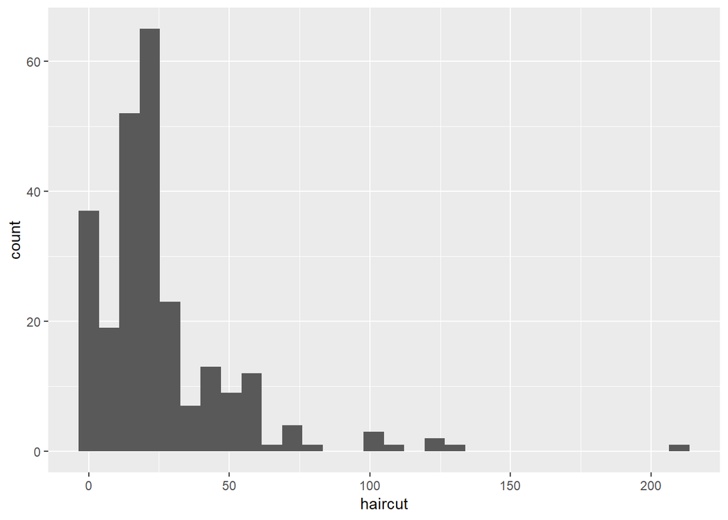

```r
ggplot(data = day1, aes(x = haircut)) +
    geom_histogram()
```

## Improving the Histogram

Let’s change the fill and color, and specify the size of the bins to be $10.

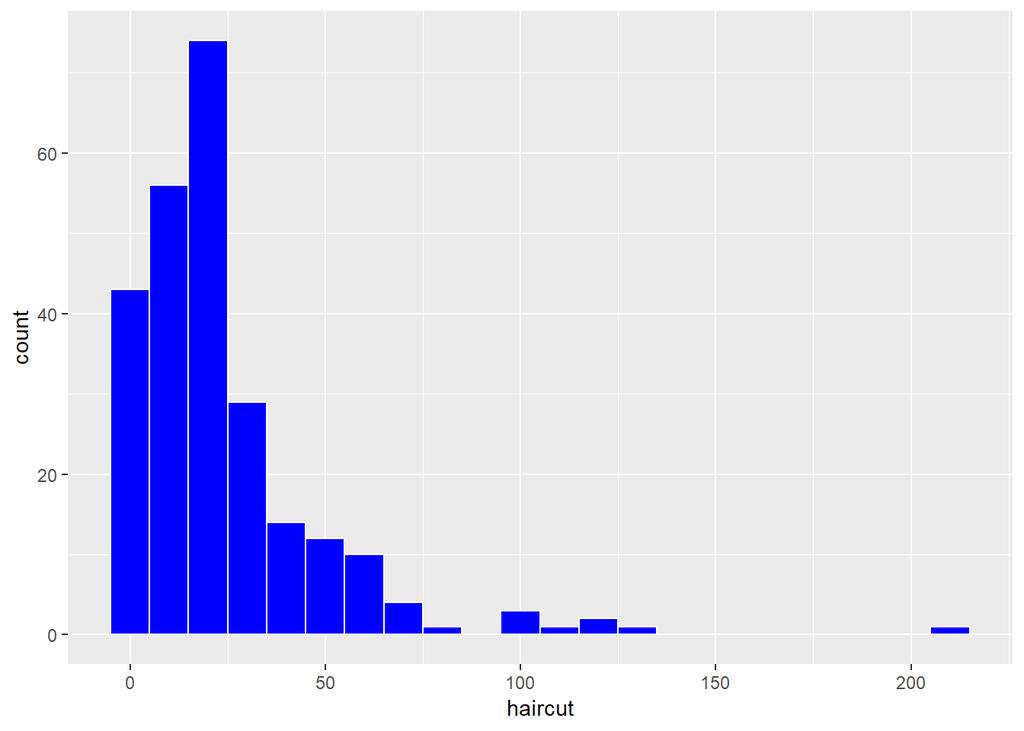

```r
ggplot(data = day1, aes(x = haircut)) +
    geom_histogram(binwidth = 10,
                   fill = "blue", color = "white")
```

Can we improve the labels?

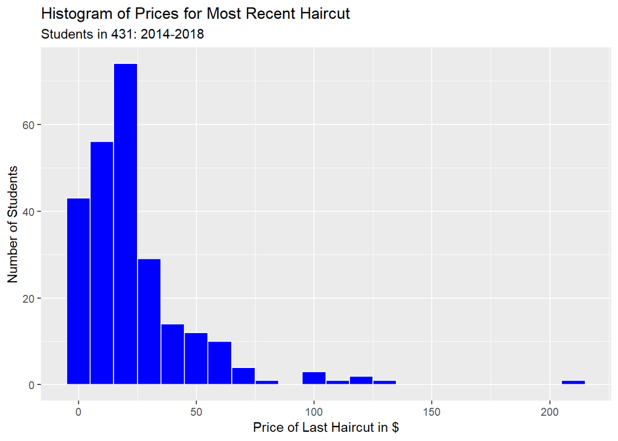

```r
ggplot(data = day1, aes(x = haircut)) +
    geom_histogram(binwidth = 10,
                   fill = "blue", color = "white") +
    labs(x = "Price of Last Haircut in $",
         y = "Number of Students",
             title = "Histogram of Prices for Most Recent Haircut",
             subtitle = "Students in 431: 2014-2018")
```

Can we eliminate that missing values issue?

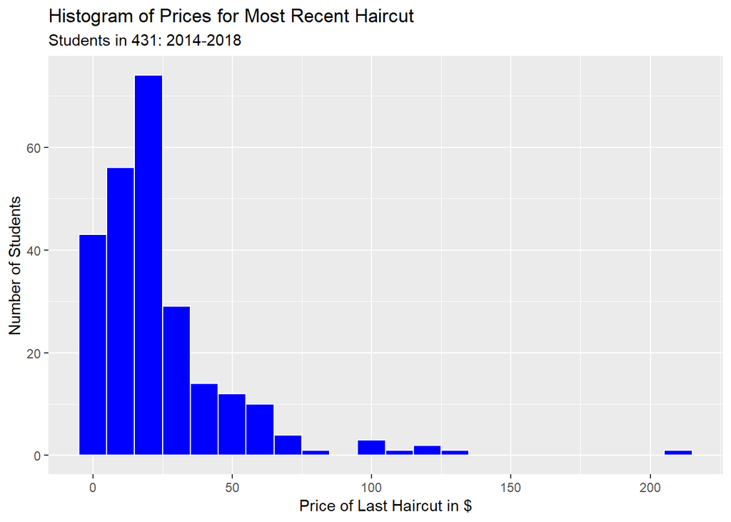

```r
day1 %>%
    filter(!is.na(haircut)) %>%
ggplot(., aes(x = haircut)) +
    geom_histogram(binwidth = 10,
                                 fill = "blue", color = "white") +
    labs(x = "Price of Last Haircut in $",
             y = "Number of Students",
             title = "Histogram of Prices for Most Recent Haircut",
             subtitle = "Students in 431: 2014-2018")
```

## Numerical Summary of Haircut Prices

```r
day1 %>%
    select(haircut) %>%
    summary()
```

```
    haircut
 Min.   :  0.00
 1st Qu.: 12.00
 Median : 20.00
 Mean   : 25.28
 3rd Qu.: 30.00
 Max.   :210.00
 NA's   :3
```

which can also be done with

```r
summary(day1$haircut)
```

```
   Min. 1st Qu.  Median    Mean 3rd Qu.    Max.    NA's
   0.00   12.00   20.00   25.28   30.00  210.00       3
```

The `mosaic` package has a useful `favstats` function…

```r
mosaic::favstats(day1$haircut)
```

```
 min Q1 median Q3 max     mean       sd   n missing
   0 12     20 30 210 25.28486 25.30809 251       3
```

But to get this in a pipeline, you’d need the `%$%` operator from the `magrittr` package…

```r
day1 %$%
    mosaic::favstats(haircut)
```

```
 min Q1 median Q3 max     mean       sd   n missing
   0 12     20 30 210 25.28486 25.30809 251       3
```

The `psych` package has a useful `describe` function…

```r
day1 %$%
    psych::describe(haircut)
```

```
   vars   n  mean    sd median trimmed   mad min max range skew
X1    1 251 25.28 25.31     20   21.28 14.83   0 210   210 2.83
   kurtosis  se
X1    13.09 1.6
```

The `Hmisc` package also has a useful `describe` function…

```r
day1 %$%
    Hmisc::describe(haircut)
```

```
haircut
       n  missing distinct     Info     Mean      Gmd      .05
     251        3       44    0.991    25.28    23.61      0.0
     .10      .25      .50      .75      .90      .95
     0.0     12.0     20.0     30.0     55.0     67.5

lowest :   0   3   5   6   7, highest: 100 110 120 130 210
```

## A more challenging question: Haircut Prices by Year

Can we build a separate plot for each year?

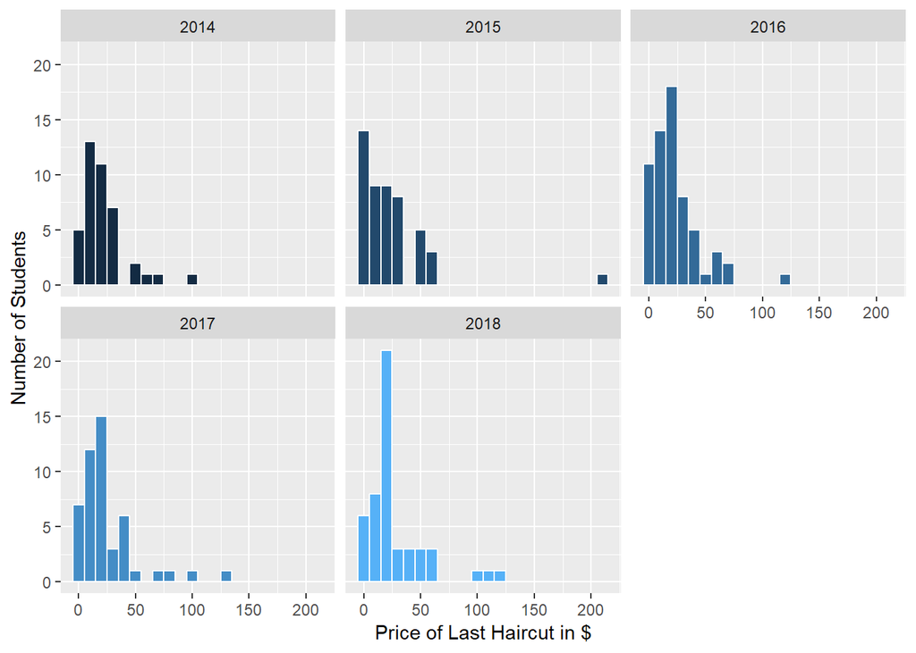

```r
day1 %>%
    filter(!is.na(haircut)) %>%
    ggplot(., aes(x = haircut, fill = year)) +
        geom_histogram(binwidth = 10, color = "white") +
        guides(fill = FALSE) +
        labs(x = "Price of Last Haircut in $",
                 y = "Number of Students") +
        facet_wrap(~ year)
```

We could use a comparison boxplot, but this requires us to get R to see `year` as a factor…

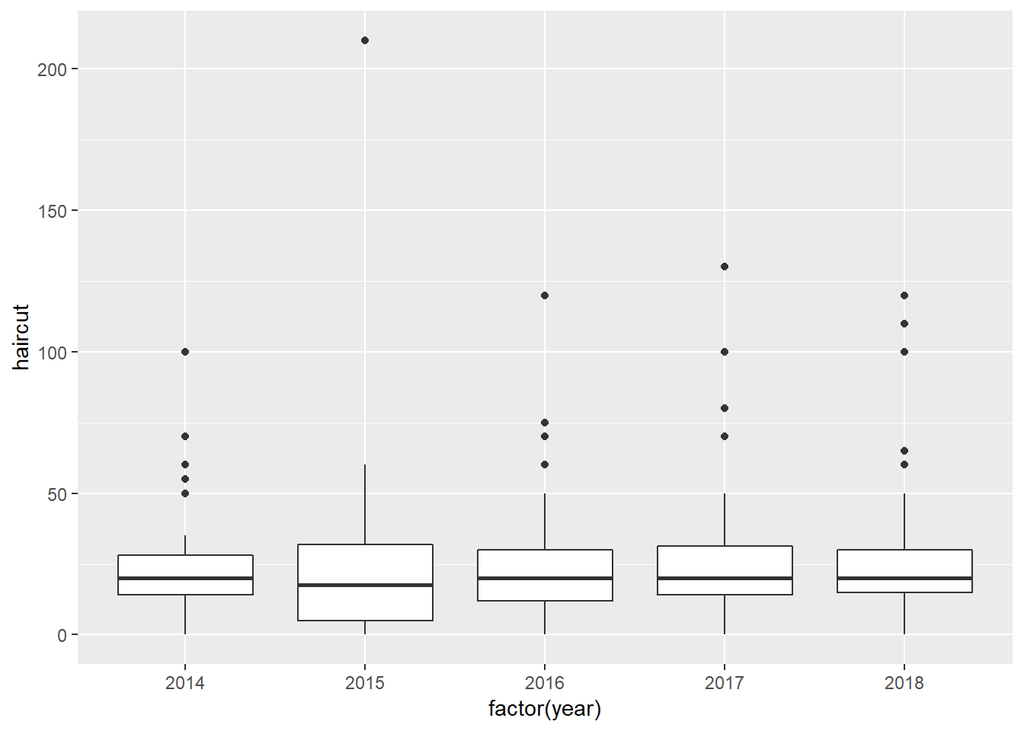

```r
ggplot(data = day1, aes(x = factor(year), y = haircut)) +
    geom_boxplot()
```

## Numerical Summary by Year?

```r
day1 %>%
    filter(!is.na(haircut)) %>%
    group_by(year) %>%
    summarize(mean = mean(haircut), sd = sd(haircut),
                        median = median(haircut))
```

```
# A tibble: 5 x 4
   year  mean    sd median
  <int> <dbl> <dbl>  <dbl>
1  2014  23.7  19.8   20
2  2015  24.7  32.8   17.5
3  2016  23.8  21.5   20
4  2017  25.9  25.3   20
5  2018  28.3  26.1   20
```

# What is the relationship between sex and guess of my age?

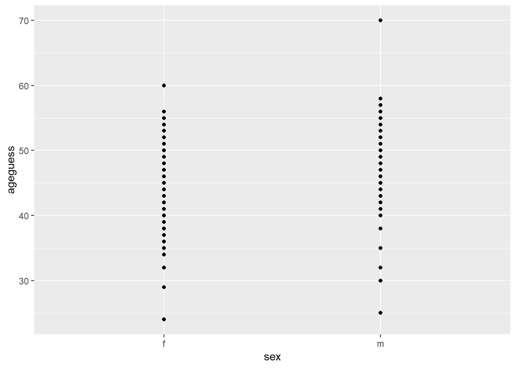

```r
day1 %>%
    filter(!is.na(ageguess)) %>%
ggplot(., aes(x = sex, y = ageguess)) +
    geom_point()
```

Let’s restrict to 2018, color the points, and jitter them left-to-right a bit.

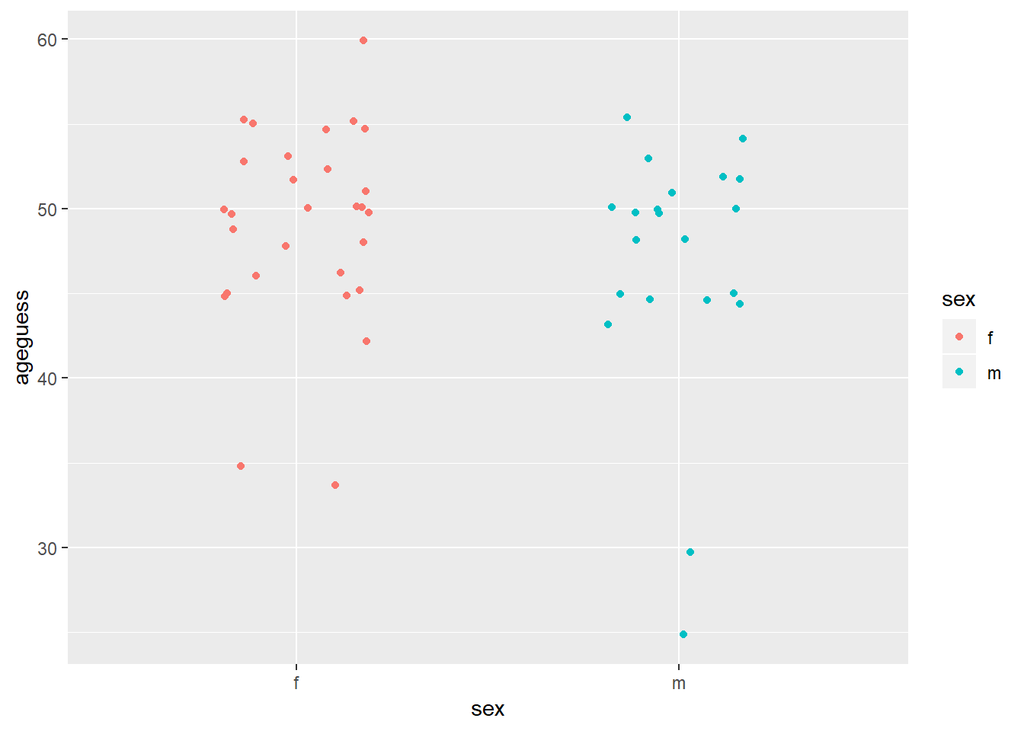

```r
day1 %>%
    filter(!is.na(ageguess), year == "2018") %>%
ggplot(., aes(x = sex, y = ageguess, col = sex)) +
    geom_jitter(width = 0.2)
```

A boxplot would be the usual summary of a quantitative variable’s association with a categorical variable. We’ll add a title, too.

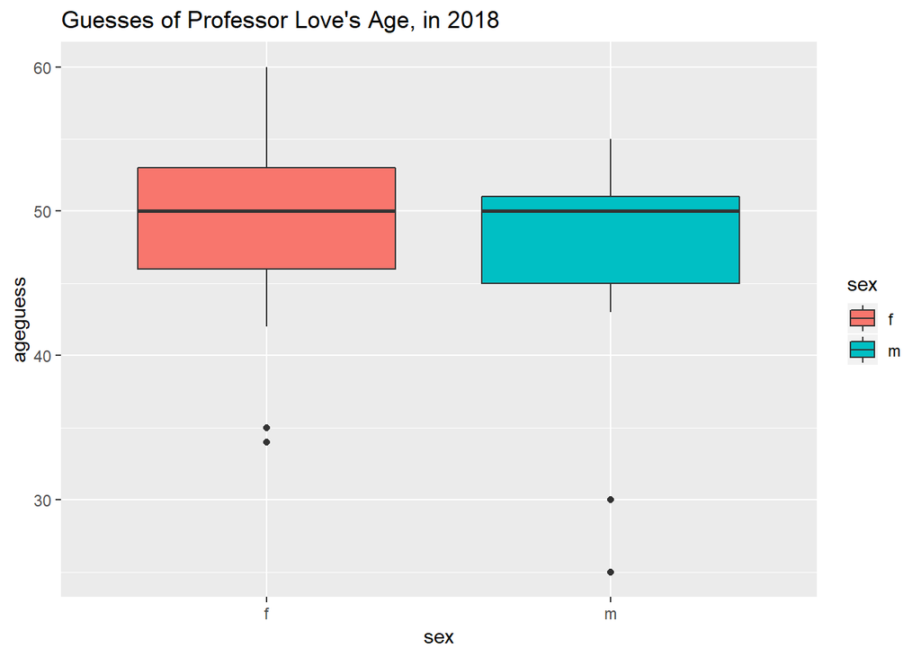

```r
day1 %>%
    filter(!is.na(ageguess), year == "2018") %>%
ggplot(., aes(x = sex, y = ageguess, fill = sex)) +
    geom_boxplot() +
    labs(title = "Guesses of Professor Love's Age, in 2018")
```

We might look at faceted histograms instead.

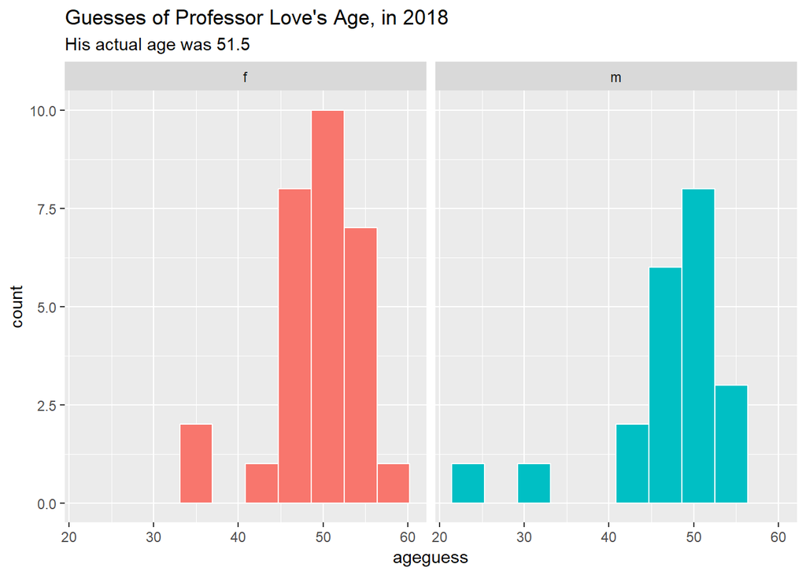

```r
day1 %>%
    filter(!is.na(ageguess), year == "2018") %>%
ggplot(., aes(x = ageguess, fill = sex)) +
    geom_histogram(bins = 10, col = "white") +
    facet_wrap(~ sex) +
      guides(fill = FALSE) +
    labs(title = "Guesses of Professor Love's Age, in 2018",
             subtitle = "His actual age was 51.5")
```

# What is the relationship between 431 students’ pulse rate and hours of sleep?

Here, we’re looking at two quantitative variables. A scatterplot is usually the best choice.

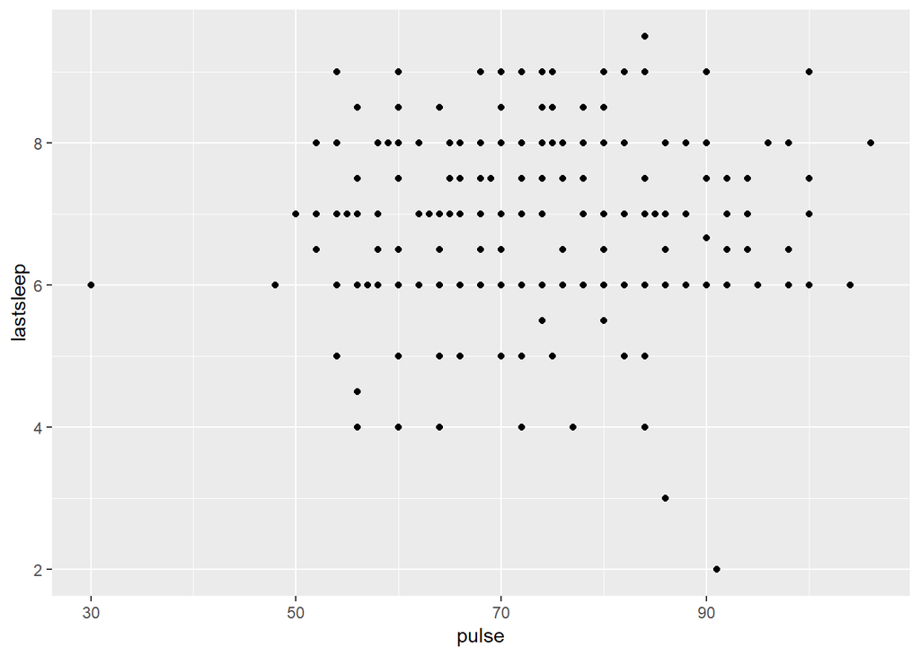

```r
ggplot(data = day1, aes(x = pulse, y = lastsleep)) +
    geom_point()
```

Let’s look at the 2018 data only, and fit a model to predict last sleep on the basis of pulse rate.

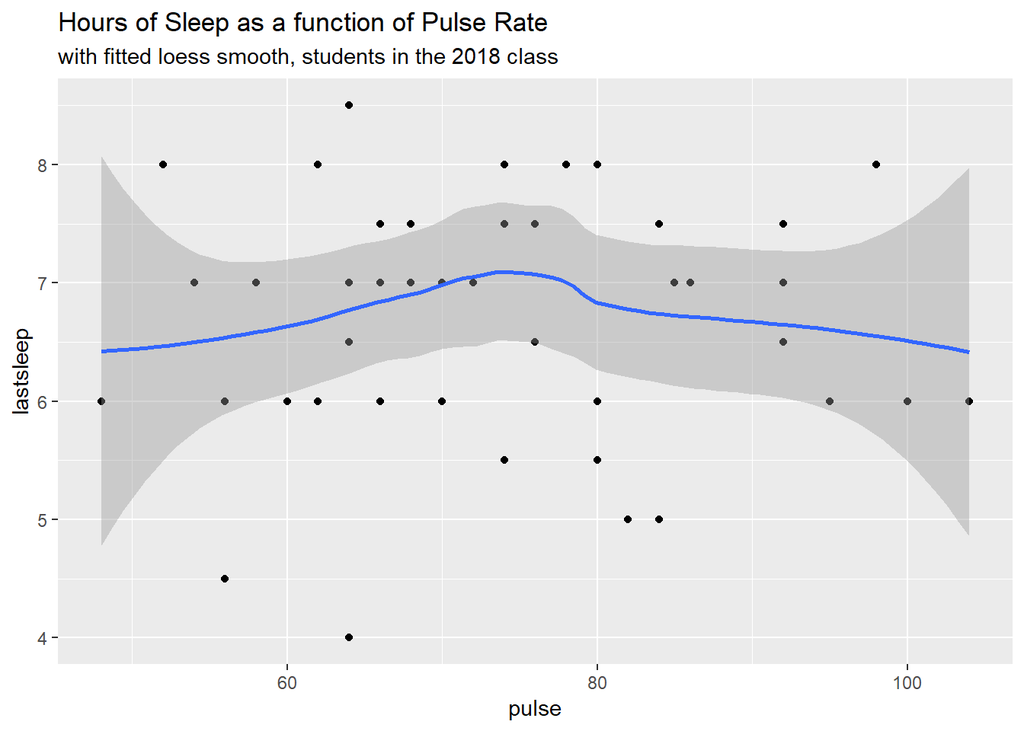

```r
day1 %>%
    filter(year == "2018") %>%
    ggplot(., aes(x = pulse, y = lastsleep)) +
    geom_point() +
    geom_smooth(method = "loess") +
    labs(title = "Hours of Sleep as a function of Pulse Rate",
         subtitle = "with fitted loess smooth, students in the 2018 class")
```

We could instead restrict ourselves to a linear model for last sleep on the basis of pulse rate.

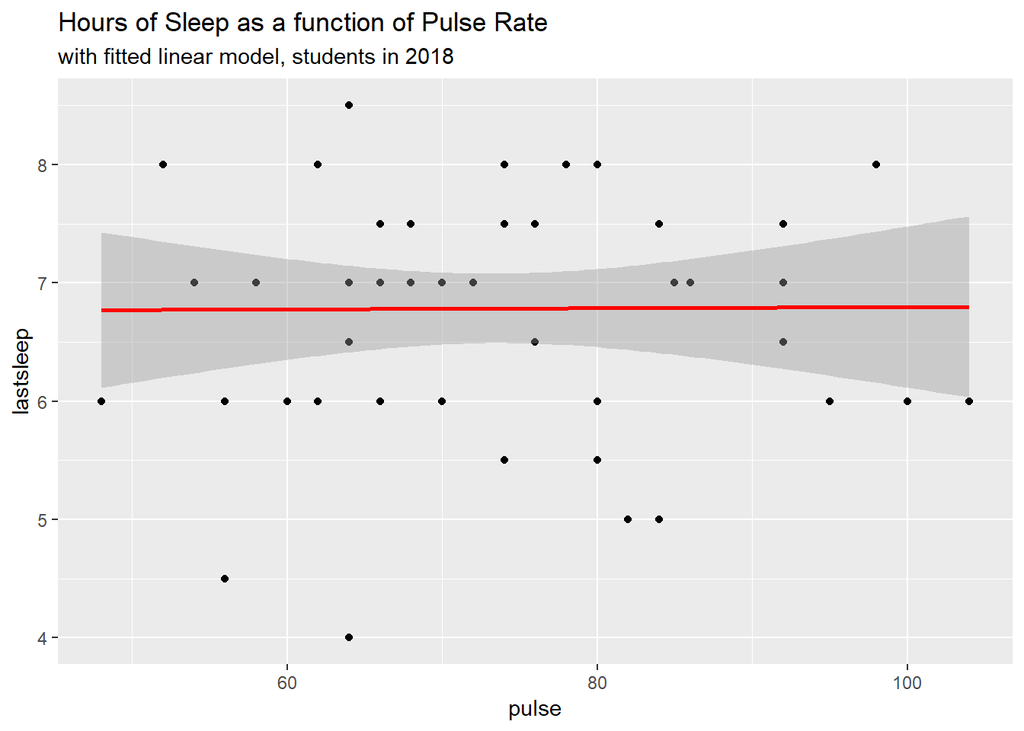

```r
day1 %>%
    filter(year == "2018") %>%
    ggplot(., aes(x = pulse, y = lastsleep)) +
    geom_point() +
    geom_smooth(method = "lm", col = "red") +
    labs(title = "Hours of Sleep as a function of Pulse Rate",
         subtitle = "with fitted linear model, students in 2018")
```

The correlation of `lastsleep` and `pulse` is likely to be of some interest. Note the use of both the `%>%` and `%$%` pipes in this case.

```r
day1 %>%
    filter(year == "2018") %$%
    cor(pulse, lastsleep)
```

```
[1] 0.006008713
```

## Does the linear model change much by year?

Here’s the plot, color coding the models by year.

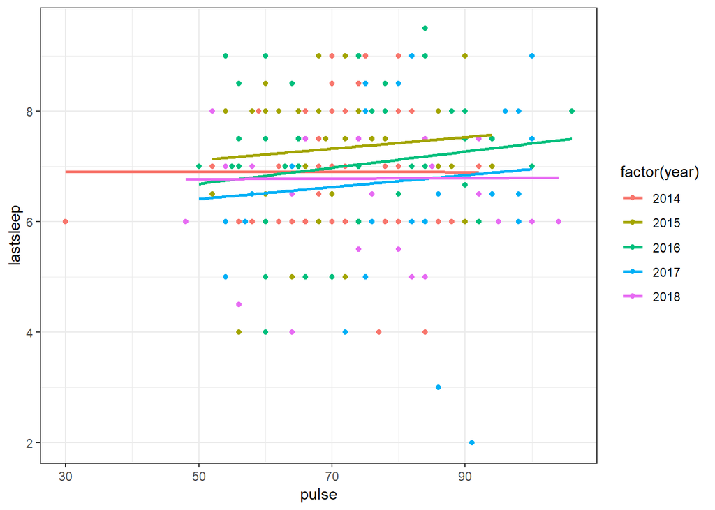

```r
day1 %>%
    filter(!is.na(pulse), !is.na(lastsleep)) %>%
    ggplot(., aes(x = pulse, y = lastsleep,
                                color = factor(year),
                                group = factor(year))) +
    geom_point() +
    geom_smooth(method = "lm", se = FALSE) +
      theme_bw()
```

Here’s the same plot of the models alone, and not showing the data (we just commented out the key line.)

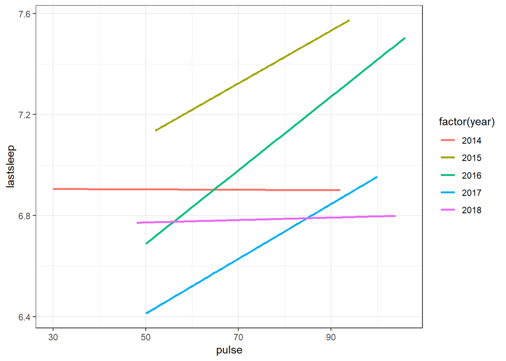

```r
day1 %>%
    filter(!is.na(pulse), !is.na(lastsleep)) %>%
    ggplot(., aes(x = pulse, y = lastsleep,
                                color = factor(year),
                                group = factor(year))) +
 #   geom_point() +
    geom_smooth(method = "lm", se = FALSE) +
      theme_bw()
```

Here’s the same basic information, but faceted by year.

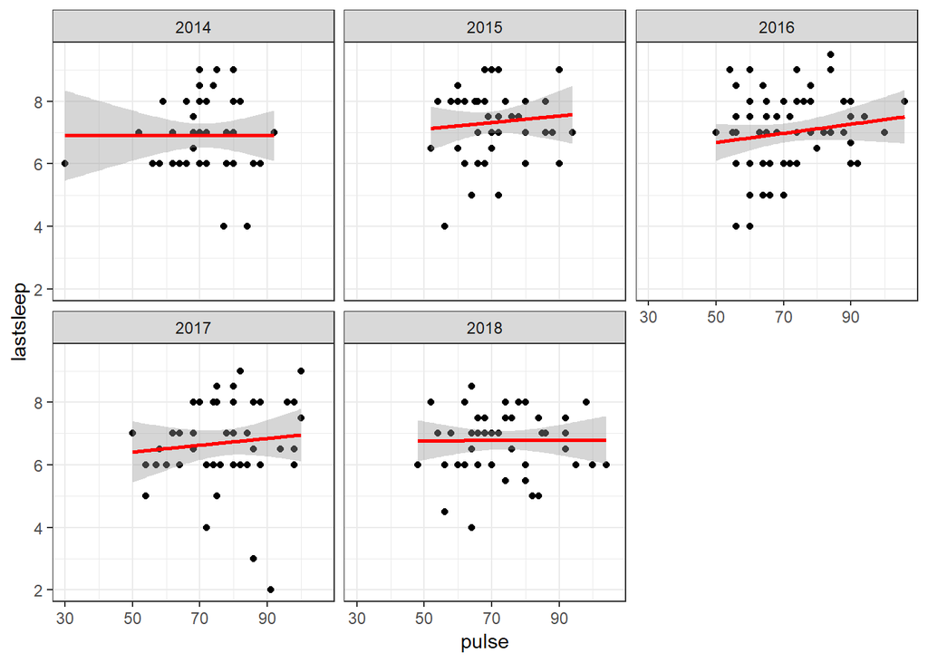

```r
day1 %>%
    filter(!is.na(pulse), !is.na(lastsleep)) %>%
    ggplot(., aes(x = pulse, y = lastsleep,
                                group = factor(year))) +
    geom_point() +
    geom_smooth(method = "lm", color = "red") +
    facet_wrap(~ year) +
      theme_bw()
```